# Temperature variability and biotic interactions explain shrub species abundance along a coastal-inland gradient in arctic Greenland

Comparison of wetness predictor power for predicting Cyperaceae & bryophyte abundance

von Oppen, J., et al. 2021

This little analysis assesses the explanatory power of different wetness proxy variables for abundance of bryophytes and Cyperaceae in the study plots (see main text for description of the sampling design). The wetness variables assessed are

- Topographic Wetness Index (TWI, [Beven and Kirkby, 1979](https://doi.org/10.1080/02626667909491834)) based on 30m GIMP MEaSUREs DEM ([Howat et al., 2017](https://doi.org/10.5067/NV34YUIXLP9W)) and Freeman FD8 flow algorithm (following Kopecky et al., 2020,
- TWI based on 30m GIMP MEaSUREs DEM and SAGA GIS flow algorithm ([Conrad et al., 2015](https://doi.org/10.5194/gmd-8-1991-2015)), and
- Tasseled-Cap Wetness Index (TCWS, [Crist and Cicone, 1984](https://doi.org/10.1109/TGRS.1984.350619)) based on original Landsat imagery.

Load and prepare species data and join with topographic data:

```r
# species data (raw pinpoint data) [from Jacob Nabe-Nielsen]
spec_nuuk <- read.csv(file.path("..", "data", "input_data", "Nuuk plant data 150201 - Pin-point data - stacked.csv")) %>%
  as_tibble

# extract abundance of focal taxa (Cyperaceae & bryophytes)
abund_cyp_plus_bry <- spec_nuuk %>%

  # filter for focal taxa
  filter(taxon %in% c("Cyperaceae", "Mosses")) %>%

  # calculate abundance per plot
  group_by(plot) %>%
  summarise(cover = sum(presence) / 25) %>%
  ungroup() %>%

  mutate(taxon = "combined") %>%

  relocate(taxon, .after = plot)
abund_cyp_bry <- spec_nuuk %>%

  # filter for focal taxa
  filter(taxon %in% c("Cyperaceae", "Mosses")) %>%

  # calculate abundance per plot
  group_by(plot, taxon) %>%
  summarise(cover = sum(presence) / 25) %>%
  ungroup() %>%

  # bind with combined cover data
  bind_rows(abund_cyp_plus_bry) %>%

  arrange(plot, taxon) %>%

  # join with topographic predictor data
  left_join(read.csv(file.path("..", "data", "processed", "nuuk_env_cover_plots_topo_variables.csv"),
                     header = T) %>%
              select(plot,
                     twi_fd8 = kopecky_twi,       # Topographic Wetness Index based on 30m GIMP MEaSUREs DEM
                                                    # and Freeman FD8 flow algorithm (Kopecky et al. 2020 SciTotEnv)
                     twi_saga = saga_twi,         # TWI based on 30m GIMP MEaSUREs DEM and SAGA GIS flow algorithm
                     tcws = TCwet_new             # Tasseled-Cap Wetness Index based on original Landsat imagery
              ) %>%
              distinct(plot, .keep_all = T),
            by = c("plot"))
```

Create a correlation matrix for wetness variables:

```r
correlate(filter(abund_cyp_bry, taxon == "combined") %>% select(-plot, -taxon))
```

```
##
## Correlation method: 'pearson'
## Missing treated using: 'pairwise.complete.obs'
```

```
## # A tibble: 4 x 5
##   rowname   cover twi_fd8 twi_saga   tcws
##   <chr>     <dbl>   <dbl>    <dbl>  <dbl>
## 1 cover    NA       0.165    0.101  0.538
## 2 twi_fd8   0.165  NA        0.864  0.247
## 3 twi_saga  0.101   0.864   NA      0.167
## 4 tcws      0.538   0.247    0.167 NA
```

TCWS is much stronger correlated with Cyperaceae + bryophyte abundance.

Fit a linear model for abundance of Cyperaceae and bryophytes combined, with wetness variables as explanatory variables:

```r
# fit linear model
summary(aov(data = filter(abund_cyp_bry, taxon == "combined"),
           formula = cover ~ tcws + twi_fd8 + twi_saga))
```

```
##              Df Sum Sq Mean Sq F value Pr(>F)
## tcws          1  14.66  14.659 167.869 <2e-16 ***
## twi_fd8       1   0.05   0.053   0.609  0.436
## twi_saga      1   0.06   0.056   0.643  0.423
## Residuals   410  35.80   0.087
## ---
## Signif. codes:  0 '***' 0.001 '**' 0.01 '*' 0.05 '.' 0.1 ' ' 1
```

Extract *R<sup>2</sup>* values for individual relationships:

```r
# extract R2 for individual relationships
# TCWS
summary(lm(data = filter(abund_cyp_bry, taxon == "combined"),
           formula = cover ~ tcws))$r.squared
```

```
## [1] 0.2898682
```

```r
# FD8 TWI
summary(lm(data = filter(abund_cyp_bry, taxon == "combined"),
           formula = cover ~ twi_fd8))$r.squared
```

```
## [1] 0.02706452
```

```r
# SAGA TWI
summary(lm(data = filter(abund_cyp_bry, taxon == "combined"),
           formula = cover ~ twi_saga))$r.squared
```

```
## [1] 0.0101119
```

TCWS has a much stronger relationship with these bright, wetness-associated vegetation types. This might indicate a potential circularity issue when using TCWS for explaining shrub abundance.

Plot relationships:

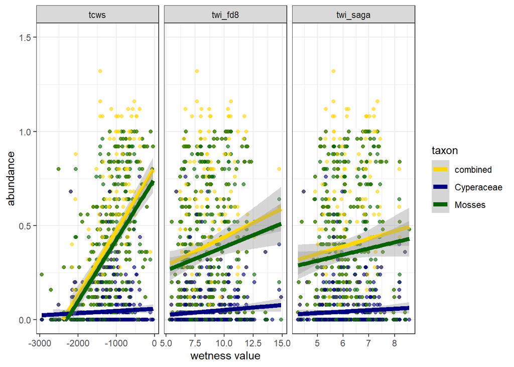

```r
# prepare plotting data
abund_cyp_bry_plot <- abund_cyp_bry %>%

  pivot_longer(cols = c("twi_fd8", "twi_saga", "tcws"),
               names_to = "wetness_var",
               values_to = "wetness_value")

# plot relationships
(comparison_plot <- ggplot(data = abund_cyp_bry_plot,
        aes(x = wetness_value,
            y = cover,
            colour = taxon)) +

    geom_point(alpha = .6) +

    geom_smooth(aes(colour = taxon),
                method = "lm",
                size = 2) +

    ylim(c(0,1.5)) +

    labs(x = "wetness value",
         y = "abundance") +

    facet_wrap(vars(wetness_var),
               scales = "free_x") +

    scale_colour_manual(values = c("gold", "navy", "darkgreen")) +

    theme_bw())
```

```r
# save_plot(file.path("figures", "nuuk_shrub_drivers_wetness_predictors_comparison.pdf"),
#           comparison_plot, base_height = 8, base_aspect_ratio = 1.2)
```